# Exponential Distribution Course Project

mjfii

2012-01-20

### Overview:

This course project report looks at a series of exponential distribution iterations, and compares the result set to a normal distribution and the theoretical mean and variance.

This report is for a Coursera Class project - Statistical Inference (Part 1). Per the project requirements, the below solution maintains the following:

> Illustrate via simulation and associated explanatory text the properties of the distribution of the mean of 40 exponentials. You should:  
> 1. Show the sample mean and compare it to the theoretical mean of the distribution.  
> 2. Show how variable the sample is (via variance) and compare it to the theoretical variance of the distribution.  
> 3. Show that the distribution is approximately normal.

### Simulations:

The simulation can be built in R using the `rexp(n,l)` function, where `n` is the number of exponentials per set, and `l`, or lambda is the rate (a constant of these purposes of 0.2). We need to build a single column data frame with the average of each of the sets. We iterate 1k times, or 1k simulations, or `s`, and use the `mean` function to calculate the average. The code is as follows:

```r
l<-0.2        # lambda
n<-40         # number of exponentials
s<-1000       # number of simulations

# initialize a data frame with a row count of the number of simulations
df<-data.frame(mean=numeric(s))

# iterate 1 to the number of simulations variable
for (i in 1:s) {
  ss<-rexp(n,l)     # simulation set of n exponential with l lambda
  df[i,1]<-mean(ss) # mean of simulation set
}
```

### Sample Mean versus Theoretical Mean:

With our sample data in place, we will compare the sample mean to the theoretical mean. The latter is defined as 1/lambda; we will define `tm` in this manner.

```r
tm<-1/l             # theoretical mean
```

```
## [1] "5.00"
```

We can define the sample mean as the average of the interated set; `am` is defined in the following manner.

```r
am<-mean(df$mean)   # actual mean
```

```
## [1] "5.01"
```

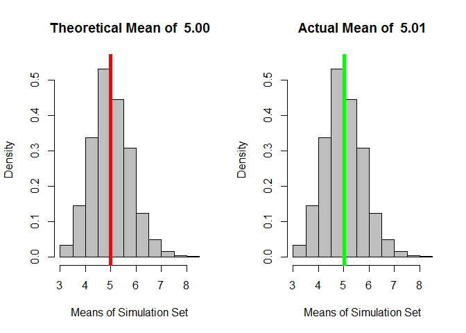

### Sample Variance versus Theoretical Variance:

We can futher compare by defining the theoretical variance as 1/lambda squared, divided by the number of exponential observations, or `n`. We will define `tv` in this way as seen below.

```r
tv<-((1/l)^2)/n     # theoretical variance
```

```
## [1] "0.625"
```

We can use the R `var` function to determine the actual variance of the observations. We can define `av` as follows.

```r
av<-var(df$mean)    # actual variance
```

```
## [1] "0.601"
```

The results of the theoretical variance as compared to actual variance are very close, as noted above. So, the sample data is ‘spread-out’ in a similar fashion to what is expected.

### Distribution:

Finally, if we plotted the a normal curve and overlayed to the sample set along with the actual distribution curve, we can see very clearly that they are very similar; in turn, the sample set can be defined as normal, in terms of distribution.

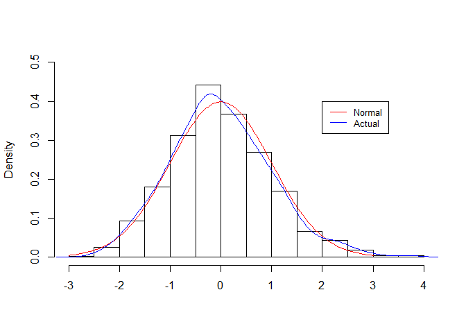

### Appendix:

A complete version of the R code is provided below, and the source code can be found here: http://github.com/mjfii/Statistical-Inference.

```r
set.seed(123456789);

l<-0.2        # lambda
n<-40         # number of exponentials
s<-1000       # number of simulations

# initialize a data frame with a row count of the number of simulations
df<-data.frame(mean=numeric(s))

# iterate 1 to the number of simulations variable
for (i in 1:s) {
  ss<-rexp(n,l)     # simulation set of n exponential with l lambda
  df[i,1]<-mean(ss) # mean of simulation set
}

# calculate the means
tm<-1/l             # theoretical mean
am<-mean(df$mean)   # actual mean

# plot the means
par(mfrow=c(1,2))
hist(df$mean,probability=T,main=paste('Theoretical Mean of ',format(round(tm,2),nsmall=2)),ylim=c(0,0.55),col='gray',xlab='Means of Simulation Set')
abline(v=tm,col='red',lwd=5)
hist(df$mean,probability=T,main=paste('Actual Mean of ',format(round(am,2),nsmall=2)),ylim=c(0,0.55),col='gray',xlab='Means of Simulation Set')
abline(v=am,col='green',lwd=5)

# calulate the variances
tv<-((1/l)^2)/n     # theoretical variance
av<-var(df$mean)

# add distribution curve
par(mfrow=c(1,1))
hist(scale(df$mean),probability=T,main='',ylim=c(0,0.5),xlab='')
curve(dnorm(x,0,1),-3,3, col='red',add=T) # normal distribution
lines(density(scale(df$mean)),col='blue') # actual distribution
legend(2,0.4,c('Normal','Actual'),cex=0.8,col=c('red','blue'),lty=1)
```